# Water Quality: Examining and Comparing Trends over Space and Time

UI Field Course at NGRREC 2023

2023-05-15

## Install and load libraries

R works with different packages that provide specific functionalities beyond what is offered from ‘base R’. In order to use the tools within a specific package, you must install and load the package within your current R session.

Here, we’re loading the packages, ‘tidyr’, ‘dplyr’ and ‘ggplot2’

tidyr and dplyr are both packages within the tidyverse family. You can read more about tidyverse here: https://www.tidyverse.org/

ggplot2 is a package used to create flexible graphics with R.

```r
# load the packages we'll need to work with
library(ggplot2)
library(tidyr)
library(dplyr)
```

If this is your first time using these packages within R, you’ll need to install them by running the following commands:

*install.packages(‘ggplot2’)*

*install.packages(‘tidyr’)*

*install.packages(‘dplyr’)*

## Set working directory

The advantage of setting a working directory at the start is that you don’t have to define a full file path every time you read in a file, so long as it resides in the defined working directory.

```r
# Set working directory to the folder that holds my data files
setwd("C:/Users/saweiss.LC/OneDrive - Lewis and Clark Community College/UI Field Course/UI-Field-Course-at-NGRREC/")
```

## Read in dataset

In order to read in your data into R, you must use the proper function that will recognize the file format of your data file. Here, we are reading in a .csv file (stands for ‘comma separated values’), which is a common file format for storing large datasets.

```r
water <- read.csv("water_example.csv")

# inspect the data
head(water) # this allows you to inspect the first 6 rows of this data frame
```

```
##                   Location      Date Year NH3_N NO3_N PO4_P TSS
## 1 MitchellCreek_UpperPiasa 5/16/2023 2023  0.02  1.55  0.05   2
## 2 MitchellCreek_UpperPiasa 5/17/2023 2023  0.01  1.20  0.05   4
## 3 MitchellCreek_UpperPiasa 5/18/2023 2023  0.01  1.10  0.04   5
## 4    AirportRd_MiddlePiasa 5/16/2023 2023  0.01  1.20  0.03   5
## 5    AirportRd_MiddlePiasa 5/17/2023 2023  0.03  1.30  0.04   6
## 6    AirportRd_MiddlePiasa 5/18/2023 2023  0.02  1.10  0.03   6
```

*NOTE: 2023 DATA WERE MADE UP FOR THE PURPOSES FOR DEMONSTRATING CODE

## Trends across consective days in 2023

The data frame we read in has past years data in it as well, but for now we just want to look at the days sampled in 2023, so we’ll create a new data frame that only includes 2023 data.

Specific columns within a data set can be called on with the ‘$’ symbol, followed by the name of the column. Below, we isolate the Year column to tell R to subset the dataset to just observations in the year 2023.

```r
# create subset for year 2023
water23 <- subset(water, water$Year == 2023)
water23
```

```
##                   Location      Date Year NH3_N NO3_N PO4_P TSS
## 1 MitchellCreek_UpperPiasa 5/16/2023 2023  0.02  1.55  0.05   2
## 2 MitchellCreek_UpperPiasa 5/17/2023 2023  0.01  1.20  0.05   4
## 3 MitchellCreek_UpperPiasa 5/18/2023 2023  0.01  1.10  0.04   5
## 4    AirportRd_MiddlePiasa 5/16/2023 2023  0.01  1.20  0.03   5
## 5    AirportRd_MiddlePiasa 5/17/2023 2023  0.03  1.30  0.04   6
## 6    AirportRd_MiddlePiasa 5/18/2023 2023  0.02  1.10  0.03   6
## 7     RockyFork_LowerPiasa 5/16/2023 2023  0.04  1.80  0.05   8
## 8     RockyFork_LowerPiasa 5/17/2023 2023  0.05  1.90  0.07   7
## 9     RockyFork_LowerPiasa 5/18/2023 2023  0.05  2.00  0.06   7
```

Let’s go ahead and graph these to see how they vary by day. To do this, we’ll use the ggplot2 package, which is a commonly used R graphing package, that allows for lots of flexible formatting options.

Since we have sites that run from upper to lower, we can tell R the logical order for those sites so that they’ll show up on the graphs in the order we would like.

```r
# Telling R the desired order for the Location variable
water23$Location <- factor(water23$Location, levels=c("MitchellCreek_UpperPiasa", "AirportRd_MiddlePiasa", "RockyFork_LowerPiasa")) # following this, you won't notice any visual change in the data frame, except for 'Location' now has the data type, 'factor'.

water23
```

```
##                   Location      Date Year NH3_N NO3_N PO4_P TSS
## 1 MitchellCreek_UpperPiasa 5/16/2023 2023  0.02  1.55  0.05   2
## 2 MitchellCreek_UpperPiasa 5/17/2023 2023  0.01  1.20  0.05   4
## 3 MitchellCreek_UpperPiasa 5/18/2023 2023  0.01  1.10  0.04   5
## 4    AirportRd_MiddlePiasa 5/16/2023 2023  0.01  1.20  0.03   5
## 5    AirportRd_MiddlePiasa 5/17/2023 2023  0.03  1.30  0.04   6
## 6    AirportRd_MiddlePiasa 5/18/2023 2023  0.02  1.10  0.03   6
## 7     RockyFork_LowerPiasa 5/16/2023 2023  0.04  1.80  0.05   8
## 8     RockyFork_LowerPiasa 5/17/2023 2023  0.05  1.90  0.07   7
## 9     RockyFork_LowerPiasa 5/18/2023 2023  0.05  2.00  0.06   7
```

#### Graphing NH3-N

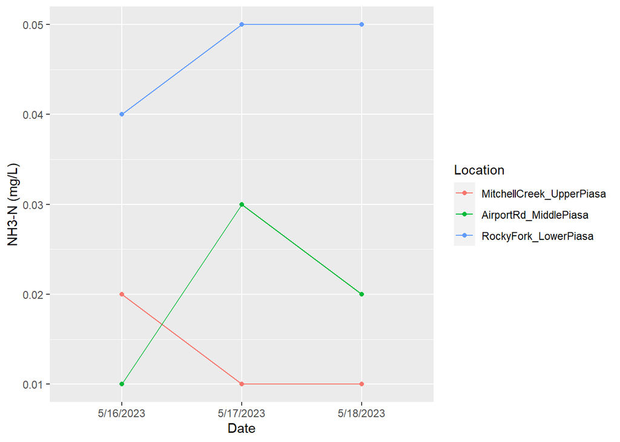

```r
NH3_N_plot <- ggplot(water23, aes(x=Date, y=NH3_N, color=Location, group=Location)) + # indicates the dataframe to use, the x axis variable (Date), y axis variable (NH3_N), and grouping variable (Location) for colors
  geom_point() + # specifies type of plot (points)
  geom_line() + # specifies type of plot (lines to connect the points)
  ylab("NH3-N (mg/L)") # y axis label

NH3_N_plot
```

#### Graphing PO4-P

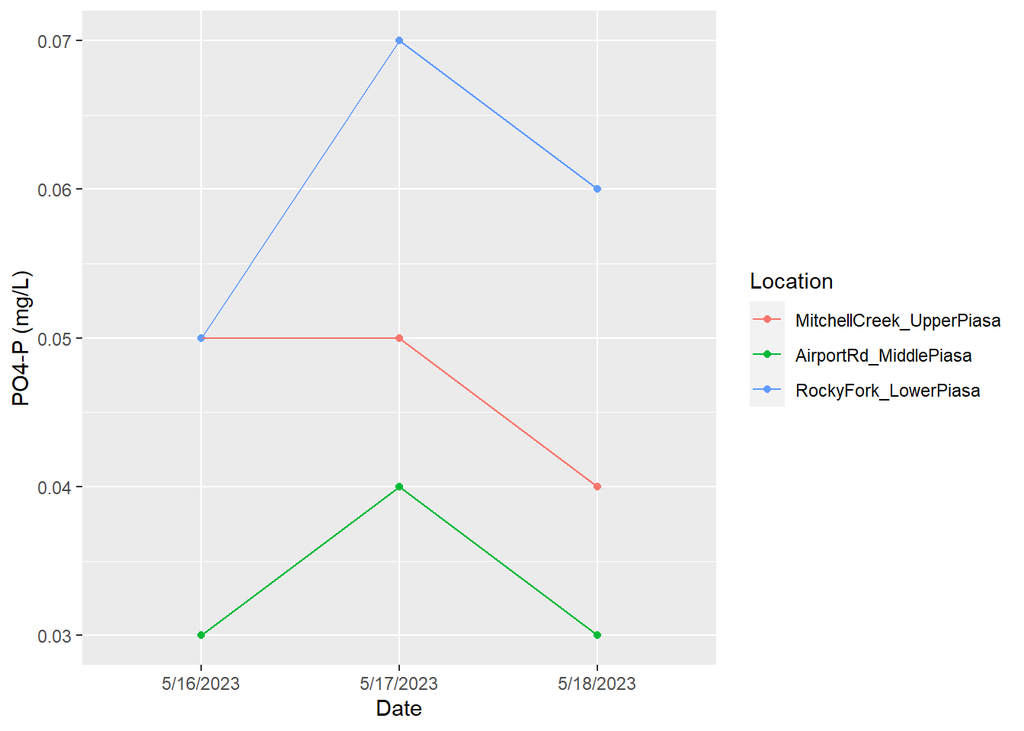

```r
PO4_P_plot <- ggplot(water23, aes(x=Date, y=PO4_P, color=Location, group=Location)) + # indicates the dataframe to use, the x axis variable (Date), y axis variable (PO4_P), and grouping variable (Location) for colors
  geom_point() + # specifies type of plot (points)
  geom_line() + # specifies type of plot (lines to connect the points)
  ylab("PO4-P (mg/L)")

PO4_P_plot
```

#### Graphing NO3-N

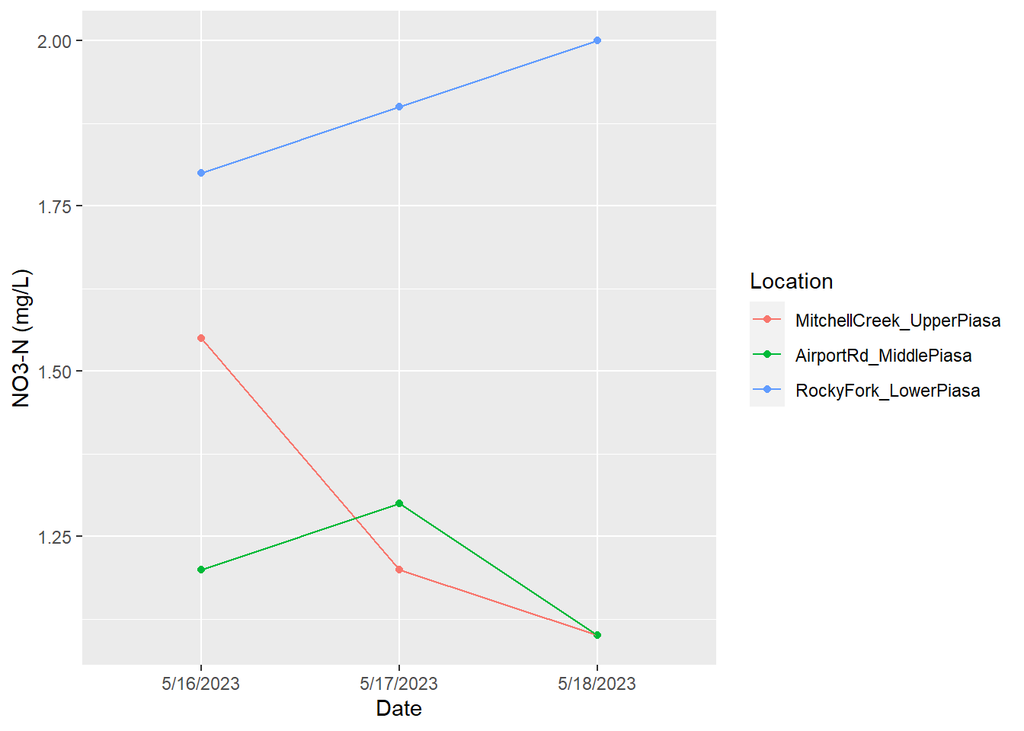

```r
NO3_N_plot <- ggplot(water23, aes(x=Date, y=NO3_N, color=Location, group=Location)) + # indicates the dataframe to use, the x axis variable (Date), y axis variable (NO3_N), and grouping variable (Location) for colors
  geom_point() + # specifies type of plot (points)
  geom_line() + # specifies type of plot (lines to connect the points)
  ylab("NO3-N (mg/L)")

NO3_N_plot
```

#### Graphing TSS

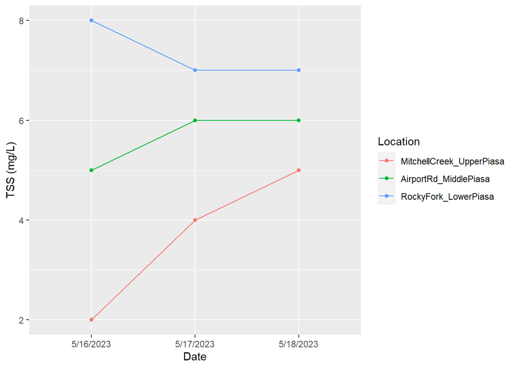

```r
TSS_plot <- ggplot(water23, aes(x=Date, y=TSS, color=Location, group=Location)) + # indicates the dataframe to use, the x axis variable (Date), y axis variable (TSS), and grouping variable (Location) for colors
  geom_point() + # specifies type of plot (points)
  geom_line() + # specifies type of plot (lines to connect the points)
  ylab("TSS (mg/L)")

TSS_plot
```

## Compare data with past years

Let’s return to our initial *water* data frame, looking at patterns across all years. Let’s see how this year compares with prior years.

To summarize the average values for each location and year, we are using the ‘group_by’ and ‘summarize’ functions from the ‘dplyr’ package. We are also using pipes (noted with ‘%>%’) to allow us to efficiently move the data through both functions in sequence.

```r
# Calculate the average value for each variable to the year, since we have multiple observations at some of the sites, and for all the 2023 sites
water_avgs <- water %>%
  group_by(Location, Year) %>% # designate the grouping variable(s). In this case, we want a single observation for each Location and Year combo.
  summarize(NH3_N = mean(NH3_N), NO3_N = mean(NO3_N), PO4_P = mean(PO4_P), TSS = mean(TSS)) # creating four new variables which are the averages of NH3_N, NO3_N, PO4_P, and TSS

water_avgs # return the resulting data frame.
```

```
## # A tibble: 12 × 6
## # Groups:   Location [3]
##    Location                  Year   NH3_N NO3_N   PO4_P   TSS
##    <chr>                    <int>   <dbl> <dbl>   <dbl> <dbl>
##  1 AirportRd_MiddlePiasa     2016  0.01    1.2   0.04   NA
##  2 AirportRd_MiddlePiasa     2017  0.09    3.34  0.07   NA
##  3 AirportRd_MiddlePiasa     2019 NA      NA    NA      NA
##  4 AirportRd_MiddlePiasa     2023  0.02    1.2   0.0333  5.67
##  5 MitchellCreek_UpperPiasa  2016  0.01    1.51  0.05   NA
##  6 MitchellCreek_UpperPiasa  2017  0.05    2.1   0.04   NA
##  7 MitchellCreek_UpperPiasa  2019 NA       2.37  0.07    1
##  8 MitchellCreek_UpperPiasa  2023  0.0133  1.28  0.0467  3.67
##  9 RockyFork_LowerPiasa      2016  0.05    2.33  0.09   NA
## 10 RockyFork_LowerPiasa      2017  0.04    1.47  0.06   NA
## 11 RockyFork_LowerPiasa      2019 NA      NA    NA      NA
## 12 RockyFork_LowerPiasa      2023  0.0467  1.9   0.06    7.33
```

Notice that not all variables have observations for every year.

Now we can plot the data. If we want to plot everything on one figure, we will have to manipulate the data from its current ‘wide’ format to a ‘long’ format, where each observed value has its own row.

```r
# go from wide to long format with the function 'pivot_longer' in the tidyr package
water_avgs_long <- pivot_longer(water_avgs, cols = NH3_N:TSS, names_to = "Variable") # cols argument is the first:last variable columns.
head(water_avgs_long)
```

```
## # A tibble: 6 × 4
## # Groups:   Location [1]
##   Location               Year Variable value
##   <chr>                 <int> <chr>    <dbl>
## 1 AirportRd_MiddlePiasa  2016 NH3_N     0.01
## 2 AirportRd_MiddlePiasa  2016 NO3_N     1.2
## 3 AirportRd_MiddlePiasa  2016 PO4_P     0.04
## 4 AirportRd_MiddlePiasa  2016 TSS      NA
## 5 AirportRd_MiddlePiasa  2017 NH3_N     0.09
## 6 AirportRd_MiddlePiasa  2017 NO3_N     3.34
```

#### Plot all years

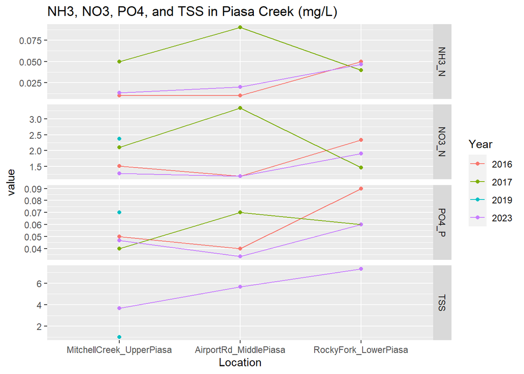

```r
water_avgs_long$Year <- as.factor(water_avgs_long$Year) # make Year a factor (right now it's 'numeric'). This will give each year a discrete color when plotting
water_avgs_long$Location <- factor(water_avgs_long$Location, levels=c("MitchellCreek_UpperPiasa", "AirportRd_MiddlePiasa", "RockyFork_LowerPiasa")) # again telling R the preferred order for these location factors (upper to lower) for this data frame

water_allyrs_plot <- ggplot(water_avgs_long, aes(x=Location, y=value, group=Year, color=Year)) + # this time we use the Year as our grouping variable
  geom_point() +
  geom_line() +
  facet_grid(rows=vars(Variable), scales="free_y") + # this plots all four graphs on the same figure, with scales set to 'free y' to allow different y-axis scales
  ggtitle("NH3, NO3, PO4, and TSS in Piasa Creek (mg/L)")

water_allyrs_plot
```

*Again, note that the 2023 data for this are made up but the other values are pulled from prior years’ data